# 시계열 데이터 프레임 (xts: Extensible Time Series)과 quantmod 패키지

- xts 자료형: 시간의 흐름에 따라 자료를 데이터 프레임 형식으로 관리함. 날짜, 시간을 키 (Key, or Index)로 자료를 관리함
- quantmod 패키지: 주가 등 금융 시계열 데이터를 관리하기 위한 도구

## 시계열 데이터 생성 (파일 읽기) 및 조회

```r
install.packages('xts')
```

```r
library(xts)
library(quantmod)
```

```r
# csv 파일을 읽음 (데이터 프레임)
stock <- read.csv('data/pairData/000210.csv')
```

```r
# stock 데이터 프레임을 xts 형으로 변환함
# 1열은 날짜이며, xts 형의 index (key)로 사용함
ohlc <- xts(stock[, c(-1, -7)], order.by=as.POSIXct(stock[,1]))
head(ohlc)
```

```
               open     high      low    close volume adjusted
2010-01-04 81472.77 83730.45 81472.77 83730.45 152530 83730.45
2010-01-05 83239.65 83730.45 82552.53 82945.17 137910 82945.17
2010-01-06 82552.53 85006.53 82552.53 84613.89 267887 84613.89
2010-01-07 84613.88 85693.64 83239.64 84417.56 266875 84417.56
2010-01-08 86184.45 86282.61 82945.17 85301.01 317395 85301.01
2010-01-11 86184.45 89227.41 85202.85 88245.81 689453 88245.81
```

```r
# 날짜를 key로 데이터 조회 (2016-02-01~2016-02-04)
ohlc['2010-01-07::2010-01-10']
```

```
               open     high      low    close volume adjusted
2010-01-07 84613.88 85693.64 83239.64 84417.56 266875 84417.56
2010-01-08 86184.45 86282.61 82945.17 85301.01 317395 85301.01
```

```r
# 2016-11-15 부터 현재까지 조회
ohlc['2017-11-15::']
```

```
            open  high   low close volume adjusted
2017-11-15 85100 85500 80800 81500 448729    81500
2017-11-16 82100 83000 81200 82700 167464    82700
2017-11-17 82700 83600 81700 82600 183433    82600
2017-11-20 83000 84300 82400 82400 153970    82400
2017-11-21 82100 82300 81000 81100 161289    81100
2017-11-22 81200 82100 81200 81700  89114    81700
```

```r
# 기타 조회 방식은 데이터 프레임과 동일함
ohlc$open[1]
```

```
               open
2010-01-04 81472.77
```

## Quantmod 패키지에 의한 주가 데이터 분석

```r
install.packages('quantmod')
```

```r
library(quantmod)
```

```r
# Google 사이트에서 삼성전자 주가 데이터 수집
s <- getSymbols('005930.KS', auto.assign=FALSE)
```

[output not shown]

```r
# 앞부분 3개 데이터 조회
head(s, 3)
```

```
           005930.KS.Open 005930.KS.High 005930.KS.Low 005930.KS.Close
2007-01-02          12400          12540         12320           12520
2007-01-03          12540          12560         12220           12280
2007-01-04          12220          12240         12060           12120
           005930.KS.Volume 005930.KS.Adjusted
2007-01-02         17607300           0.329870
2007-01-03         19676500           0.323546
2007-01-04         18258900           0.319331
```

```r
# 뒷부분 3개 데이터 조회
tail(s, 3)
```

```
           005930.KS.Open 005930.KS.High 005930.KS.Low 005930.KS.Close
2019-11-07          53400          53400         52400           52900
2019-11-08          53200          53300         52000           52100
2019-11-11          52200          52200         51400           51600
           005930.KS.Volume 005930.KS.Adjusted
2019-11-07          9257116              52900
2019-11-08         11603290              52100
2019-11-11          8168554              51600
```

```r
# 2010-01-01 ~ 현재까지 데이터 수집
s <- getSymbols('005930.KS', from='2010-01-01', auto.assign=FALSE)
```

# xts, quantmod 사용 예시

## 수익률, 연평균 수익률, 연평균 변동성 계산

```r
s <- getSymbols('005930.KS', from='2010-01-01', auto.assign=FALSE)
colnames(s) <- c('open', 'high', 'low', 'close', 'volume', 'adjusted')

# 거래량 = 0 인 데이터를 제외함
s <- s[Vo(s) > 0]

# 종가 기준 수익률 계산
s$rtn <- ROC(Cl(s))

head(s, 3)
```

```
            open  high   low close   volume adjusted        rtn
2010-01-04 16060 16180 16000 16180 11950800 5.854249         NA
2010-01-05 16520 16580 16300 16440 27925850 5.948323 0.01594148
2010-01-06 16580 16820 16520 16820 22948850 6.085815 0.02285126
```

```r
s <- na.omit(s)
head(s, 3)
```

```
            open  high   low close   volume adjusted         rtn
2010-01-05 16520 16580 16300 16440 27925850 5.948323  0.01594148
2010-01-06 16580 16820 16520 16820 22948850 6.085815  0.02285126
2010-01-07 16820 16820 16260 16260 22107950 5.883196 -0.03386055
```

```r
# 연 평균 수익률
drift <- mean(s$rtn) * 252 * 100
drift
```

12.0717030869891

```r
# 연 평균 변동성
volatility <- sd(s$rtn) * sqrt(252) * 100
volatility
```

26.9690815252477

## 주가, 수익률 차트 작성

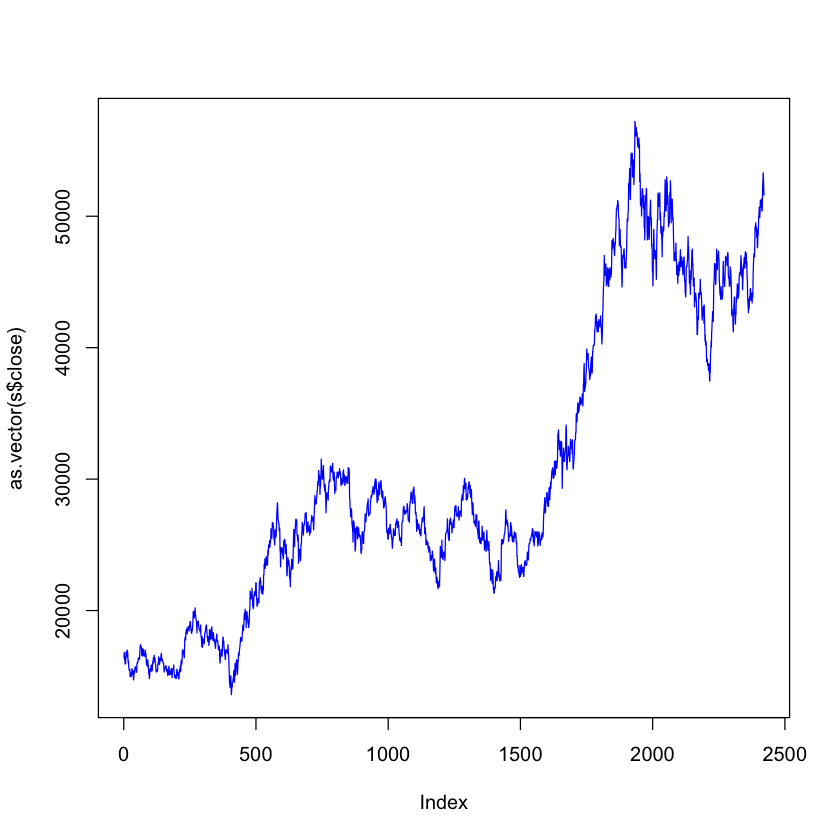

```r
plot(as.vector(s$close), type='l', col='blue')
```

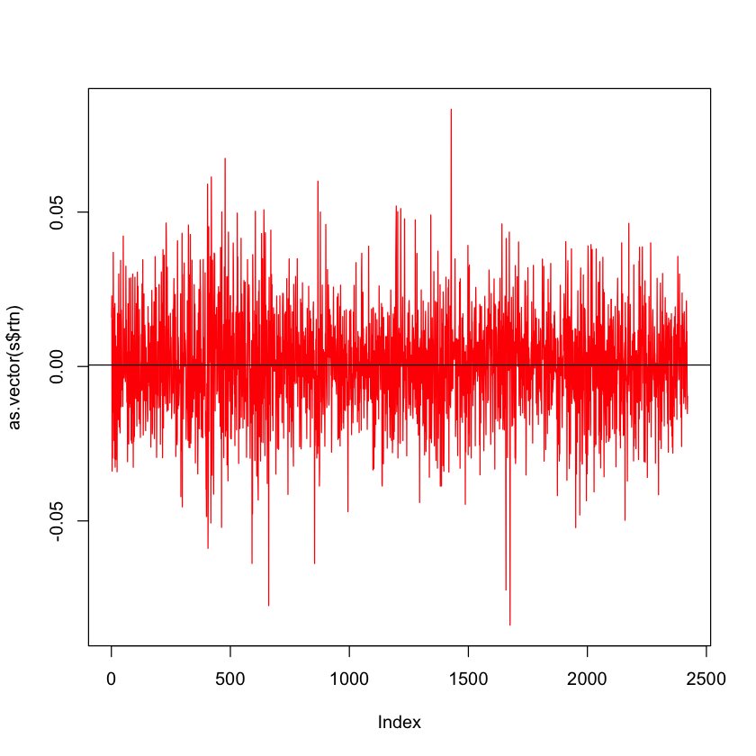

```r
plot(as.vector(s$rtn), type='l', col='red')
abline(h=mean(s$rtn))
```

## 일일 수익률 분포

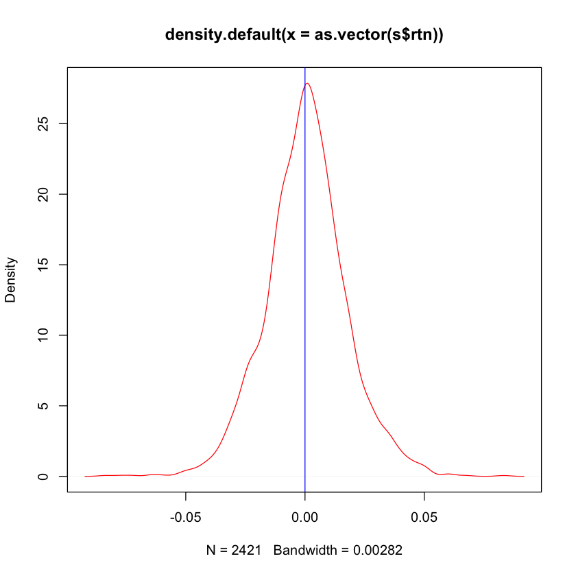

```r
plot(density(as.vector(s$rtn)), col = 'red')
abline(v = 0, col = 'blue')
```

```r
# 수익률의 평균
mean(s$rtn)
```

0.000479035836785283

```r
# 수익률의 표준편차
sd(s$rtn)
```

0.0169889244770552

## 거래량 차트, 이동평균 차트

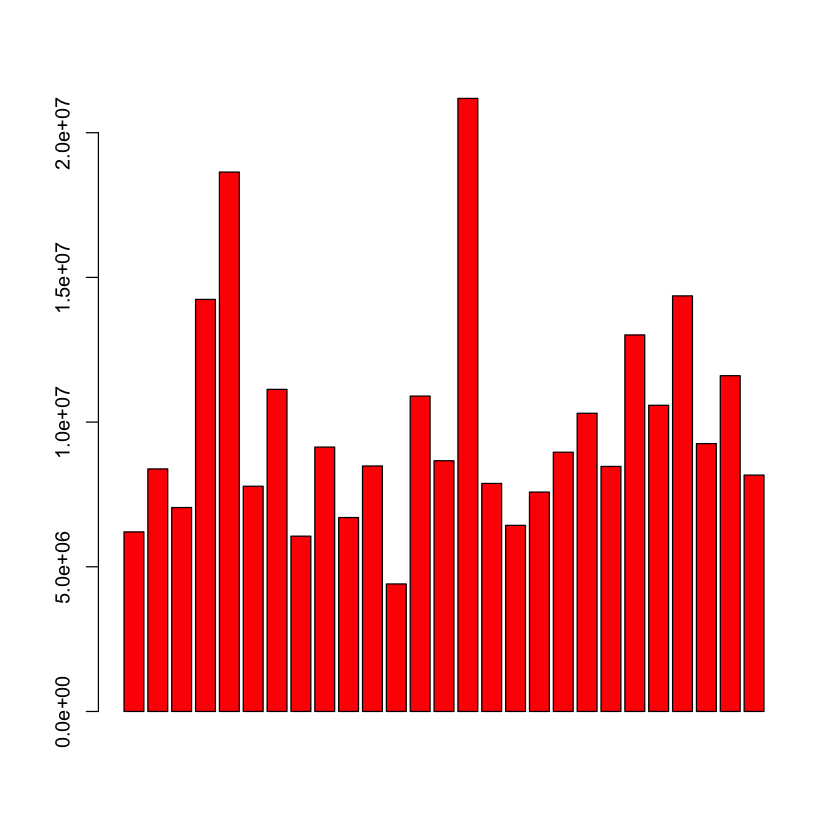

```r
barplot(as.vector(s$volume['2019-10-01::']), col='red')
```

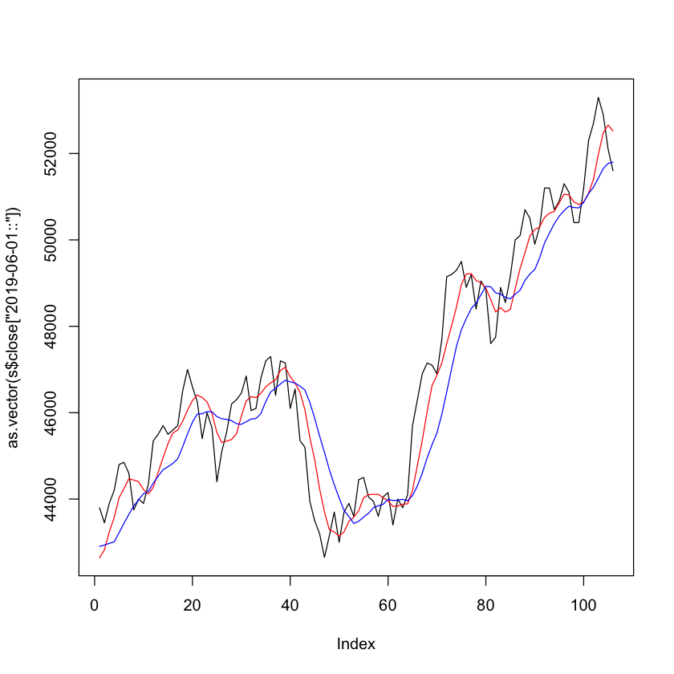

```r
s$sma5 <- SMA(s$close, 5)
s$sma10 <- SMA(s$close, 10)
plot(as.vector(s$close['2019-06-01::']), type='l')
lines(as.vector(s$sma5['2019-06-01::']), col='red')
lines(as.vector(s$sma10['2019-06-01::']), col='blue')
```

# quantmod 사용 예시 - 주가 차트 작성 (주가의 일일 캔들 차트 및 기술적 분석 지표)

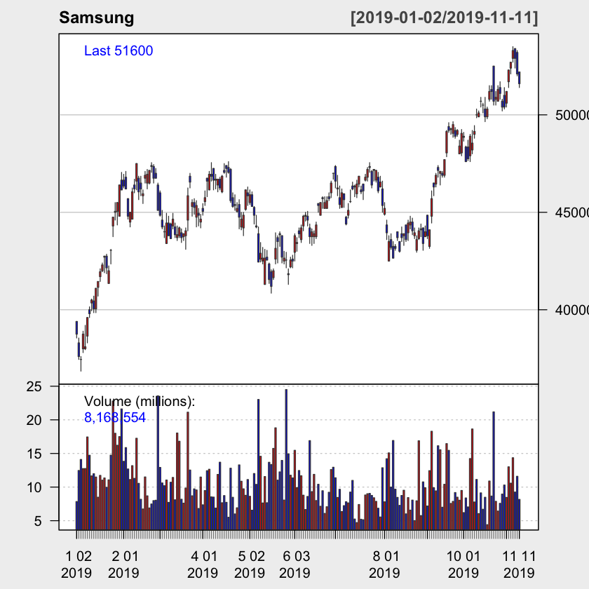

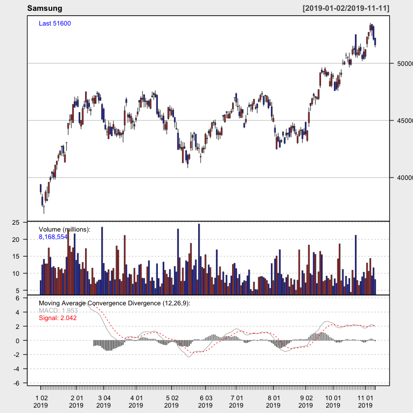

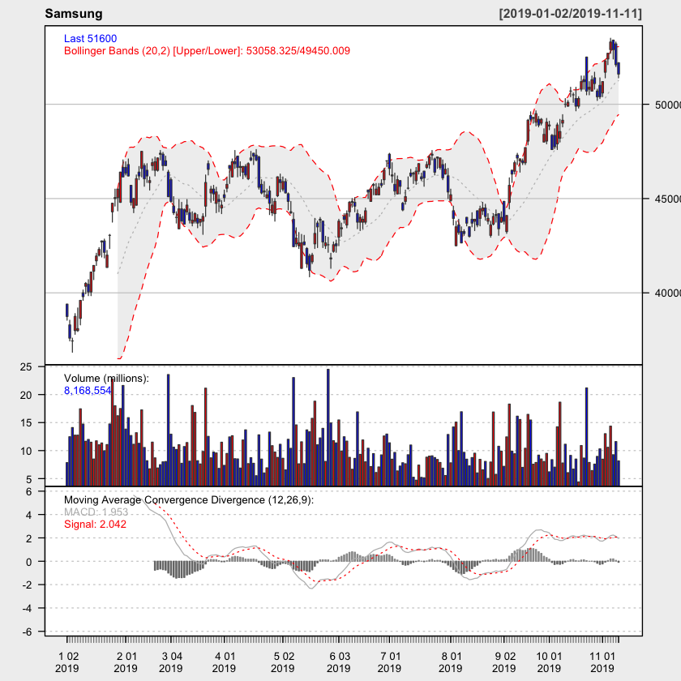

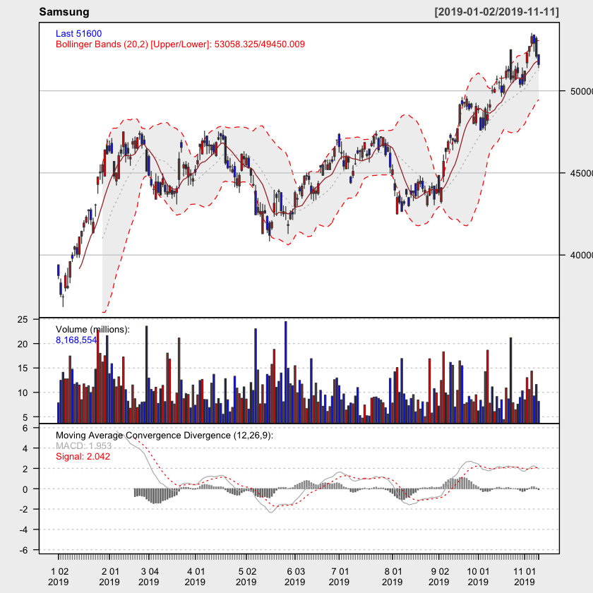

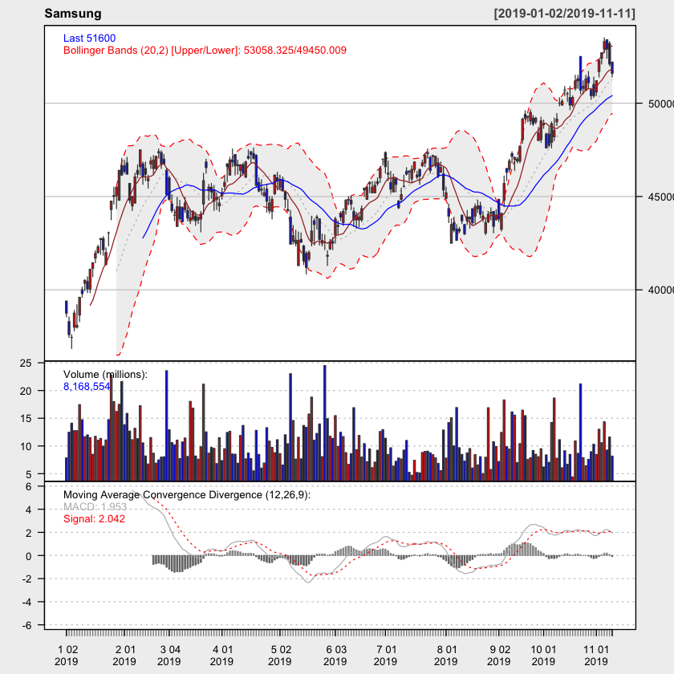

```r
chartSeries(s['2019-01-01::'], up.col='red', dn.col='blue', theme='white', name='Samsung')

# CCS 기술적 지표 추가
addMACD()

# 볼린저 밴드 추가
addBBands()

# 10일, 30일 이동평균선 추가
addSMA(10); addSMA(30, col='blue')
```

# quantmod 사용 예시 - 주가 차트 작성 (주가의 주간 혹은 월간 캔들 차트 및 기술적 분석 지표)

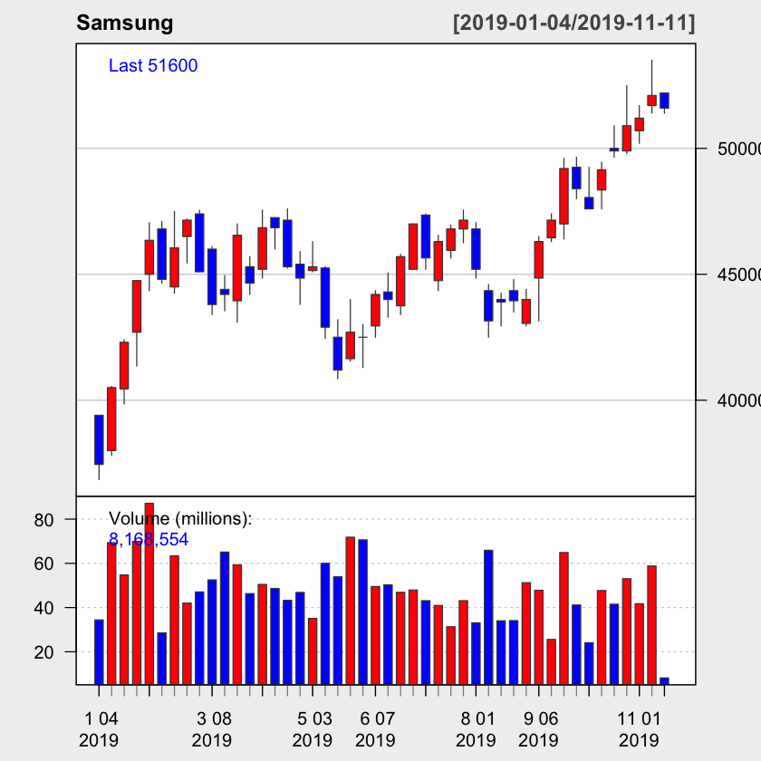

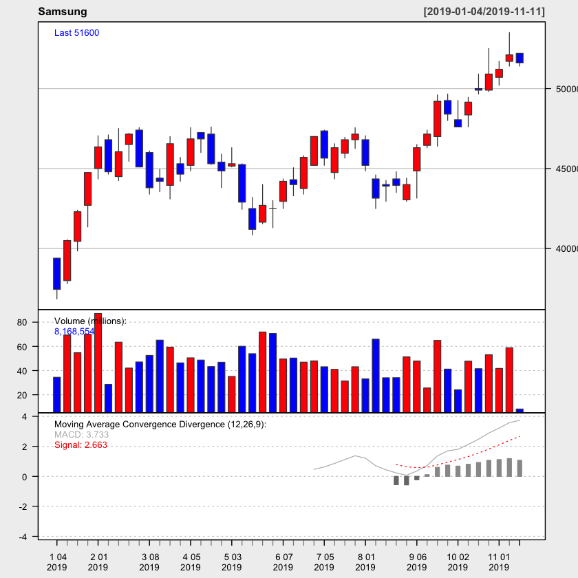

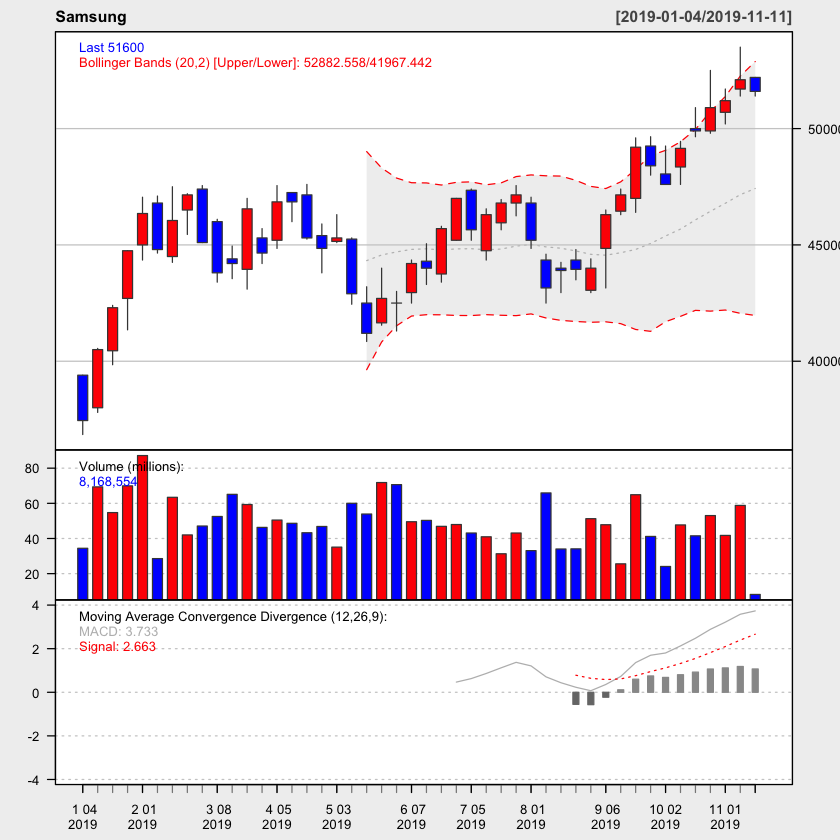

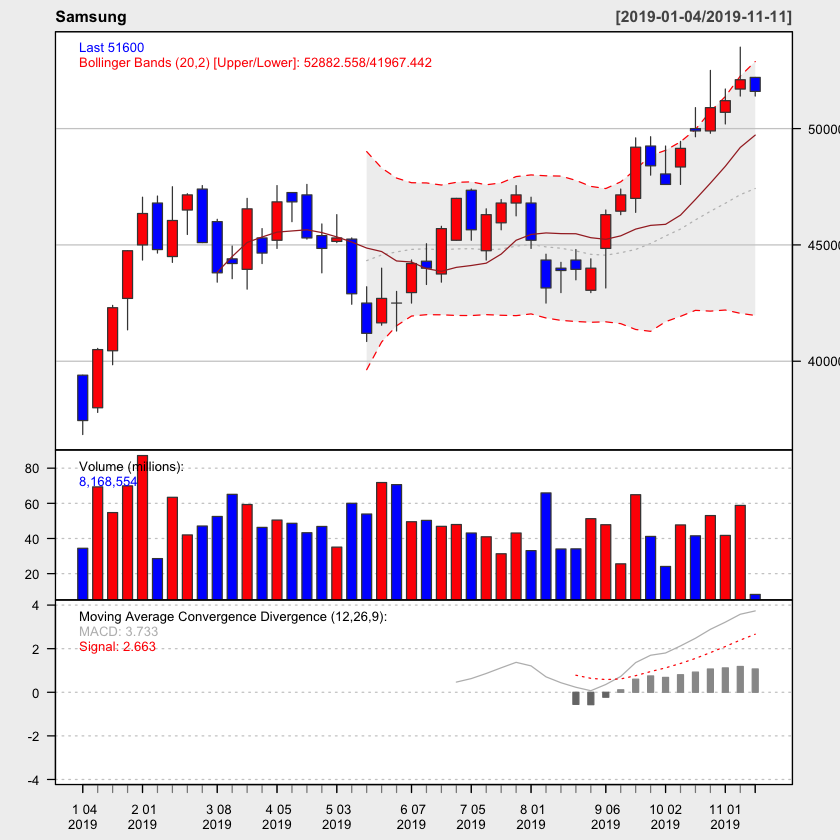

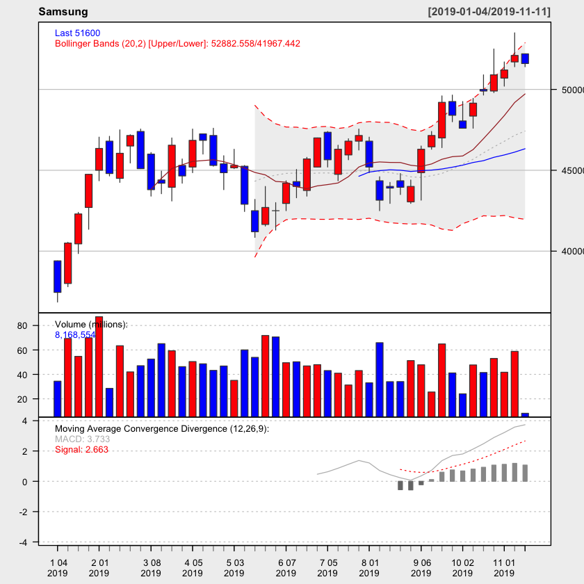

```r
chartSeries(to.weekly(s['2019-01-01::']), up.col='red', dn.col='blue', theme='white', name='Samsung')

# CCS 기술적 지표 추가
addMACD()

# 볼린저 밴드 추가
addBBands()

# 10일, 30일 이동평균선 추가, 월봉은 to.monthly() 사용
addSMA(10); addSMA(30, col='blue')
```